# DRD_2026_Lesson_6

```r
rm(list=ls())
setwd("~/Dropbox/DRD_2026/6")
```

For these last analyses, we will use the object final_ttest_first20k, that we previously prepared by applying the ttest function to the first 20000 rows of the beta_preprocessQuantile dataframe. If it is not present in your workspace or in Lesson 5 folder, you can download it from Lesson 6 folder:

```r
load("final_ttest_first20k.RData")
str(final_ttest_first20k)
```

```
## 'data.frame':    20000 obs. of  9 variables:
##  $ X9344737127_R01C02    : num  0.4091 0.3215 0.0417 0.2026 0.6431 ...
##  $ X9344737127_R03C02    : num  0.404 0.3075 0.0432 0.2525 0.586 ...
##  $ X9344737127_R06C01    : num  0.3468 0.2447 0.0524 0.4507 0.3696 ...
##  $ X9344737127_R02C02    : num  0.3652 0.2544 0.0526 0.4293 0.3664 ...
##  $ X9376538140_R02C01    : num  0.4237 0.3034 0.0432 0.1735 0.5723 ...
##  $ X9376538140_R05C01    : num  0.4131 0.329 0.0433 0.1796 0.6568 ...
##  $ X9376538140_R01C01    : num  0.3445 0.238 0.0557 0.3805 0.4218 ...
##  $ X9376538140_R04C01    : num  0.35 0.231 0.053 0.376 0.437 ...
##  $ pValues_ttest_first20k: num  7.37e-05 9.75e-05 1.35e-04 1.98e-04 2.49e-04 ...
```

```r
ls()
```

```
## [1] "final_ttest_first20k"
```

If the pheno object is not present in your workspace, you can load it again from Lesson 3 folder:

```r
pheno <- read.csv("~/Dropbox/DRD_2026/3/Input_data/SampleSheet.csv",header=T, stringsAsFactors=T)
str(pheno)
```

```
## 'data.frame':    8 obs. of  7 variables:
##  $ Sample_ID  : int  21050 21060 22041 22051 21090 21100 23081 23091
##  $ Sample_Well: Factor w/ 8 levels "A11","A12","E11",..: 6 1 4 7 5 2 3 8
##  $ Array      : Factor w/ 8 levels "R01C01","R01C02",..: 2 5 8 4 3 7 1 6
##  $ Slide      : num  9.34e+09 9.34e+09 9.34e+09 9.34e+09 9.38e+09 ...
##  $ Group      : Factor w/ 2 levels "A","B": 1 1 2 2 1 1 2 2
##  $ Gender     : Factor w/ 2 levels "F","M": 1 1 1 1 1 1 1 2
##  $ BMI        : num  21.6 20.8 26.6 26.6 17.5 ...
```

# CHUNK 1: multiple test correction

We will use the function p.adjust to perform the multiple test correction. For the sake of semplicity, we will focus on the results of the ttest, but you can apply the same procedure also to the p-values resulting from the non parametric test.

```r
?p.adjust
```

We will apply the Benjamini & Hochberg and the Bonferroni corrections:

```r
corrected_pValues_BH <- p.adjust(final_ttest_first20k$pValues_ttest_first20k,"BH")
corrected_pValues_Bonf <- p.adjust(final_ttest_first20k$pValues_ttest_first20k,"bonferroni")
final_ttest_first20k_corrected <- data.frame(final_ttest_first20k, corrected_pValues_BH, corrected_pValues_Bonf)
head(final_ttest_first20k_corrected)
```

```
##            X9344737127_R01C02 X9344737127_R03C02 X9344737127_R06C01
## cg00147160         0.40907489         0.40395268         0.34677567
## cg14914422         0.32145688         0.30750562         0.24472666
## cg09473867         0.04168016         0.04317311         0.05235453
## cg25978218         0.20257688         0.25247419         0.45067145
## cg18154117         0.64307543         0.58601626         0.36963643
## cg11799650         0.20758273         0.22121794         0.34532280
##            X9344737127_R02C02 X9376538140_R02C01 X9376538140_R05C01
## cg00147160         0.36517947         0.42370284          0.4131399
## cg14914422         0.25437815         0.30339207          0.3290041
## cg09473867         0.05255956         0.04322238          0.0433248
## cg25978218         0.42926544         0.17350541          0.1796035
## cg18154117         0.36635971         0.57234962          0.6567593
## cg11799650         0.29937972         0.19707495          0.1733119
##            X9376538140_R01C01 X9376538140_R04C01 pValues_ttest_first20k
## cg00147160         0.34446583         0.34958276           7.371467e-05
## cg14914422         0.23800262         0.23057053           9.750103e-05
## cg09473867         0.05566484         0.05299677           1.349507e-04
## cg25978218         0.38048423         0.37558371           1.977524e-04
## cg18154117         0.42184015         0.43663288           2.490115e-04
## cg11799650         0.32566641         0.29110664           4.283231e-04
##            corrected_pValues_BH corrected_pValues_Bonf
## cg00147160            0.6453685                      1
## cg14914422            0.6453685                      1
## cg09473867            0.6453685                      1
## cg25978218            0.6453685                      1
## cg18154117            0.6453685                      1
## cg11799650            0.6453685                      1
```

We can visualize the distributions of the p-values and of the corrected p-values by boxplots:

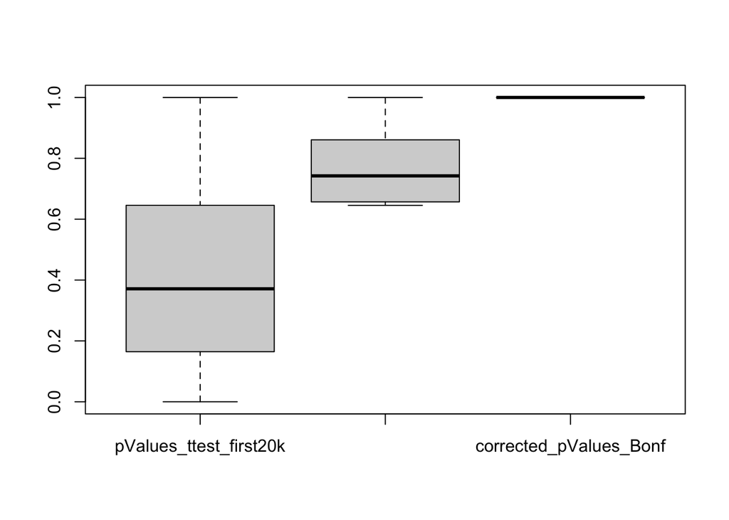

```r
boxplot(final_ttest_first20k_corrected[,9:11])
```

How many probes survive the multiple test correction?

```r
dim(final_ttest_first20k_corrected[final_ttest_first20k_corrected$pValues_ttest<=0.05,])
```

```
## [1] 1438   11
```

```r
dim(final_ttest_first20k_corrected[final_ttest_first20k_corrected$corrected_pValues_BH<=0.05,])
```

```
## [1]  0 11
```

```r
dim(final_ttest_first20k_corrected[final_ttest_first20k_corrected$corrected_pValues_Bonf<=0.05,])
```

```
## [1]  0 11
```

# CHUNK 2: Volcano plots

First of all, we have to calculate the difference between the averge of group A values and the average of group B values. To this aim, we will first create two matrixes containing the beta-values of group A and group B samples, and then we will calculate the mean within each group for each row.

```r
pheno$Group
```

```
## [1] A A B B A A B B
## Levels: A B
```

```r
beta_first20k <- final_ttest_first20k_corrected[,1:8]
```

```r
beta_first20k_groupA <- beta_first20k[,pheno$Group=="A"]
mean_beta_first20k_groupA <- apply(beta_first20k_groupA,1,mean)
beta_first20k_groupB <- beta_first20k[,pheno$Group=="B"]
mean_beta_first20k_groupB <- apply(beta_first20k_groupB,1,mean)
```

Now we can calculate the difference between average values:

```r
delta_first20k <- mean_beta_first20k_groupB-mean_beta_first20k_groupA
head(delta_first20k)
```

```
##  cg00147160  cg14914422  cg09473867  cg25978218  cg18154117  cg11799650
## -0.06096666 -0.07342018  0.01054381  0.20696121 -0.21593287  0.11557201
```

Now we create a dataframe with two columns, one containing the delta values and the other with the -log10 of p-values

```r
toVolcPlot <- data.frame(delta_first20k, -log10(final_ttest_first20k_corrected$pValues_ttest))
head(toVolcPlot)
```

```
##            delta_first20k X.log10.final_ttest_first20k_corrected.pValues_ttest.
## cg00147160    -0.06096666                                              4.132446
## cg14914422    -0.07342018                                              4.010991
## cg09473867     0.01054381                                              3.869825
## cg25978218     0.20696121                                              3.703878
## cg18154117    -0.21593287                                              3.603781
## cg11799650     0.11557201                                              3.368229
```

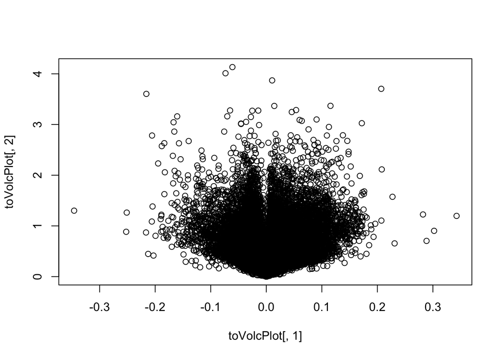

```r
plot(toVolcPlot[,1], toVolcPlot[,2])
```

Let’s improve a bit the plot: http://www.statmethods.net/advgraphs/parameters.html We can also add a threshold for pvalue significance (for example, 0.01) by using the abline function

```r
plot(toVolcPlot[,1], toVolcPlot[,2],pch=16,cex=0.5)
-log10(0.01)
```

```
## [1] 2
```

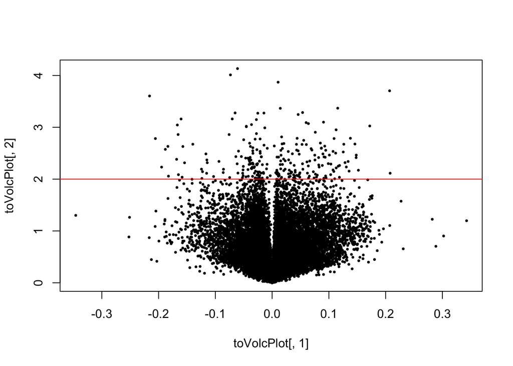

```r
?abline
abline(h=-log10(0.01),col="red")
```

Now I want to highlight the probes (that is, the points), that have a nominal pValue<0.01 and a delta > 0.1)

```r
plot(toVolcPlot[,1], toVolcPlot[,2],pch=16,cex=0.5)
toHighlight <- toVolcPlot[toVolcPlot[,1]>0.1 & toVolcPlot[,2]>(-log10(0.01)),]
head(toHighlight)
```

```
##            delta_first20k X.log10.final_ttest_first20k_corrected.pValues_ttest.
## cg25978218      0.2069612                                              3.703878
## cg11799650      0.1155720                                              3.368229
## cg04542977      0.1719873                                              3.025450
## cg24254842      0.1127347                                              2.951444
## cg04885881      0.1379048                                              2.787783
## cg02367921      0.1091145                                              2.783046
```

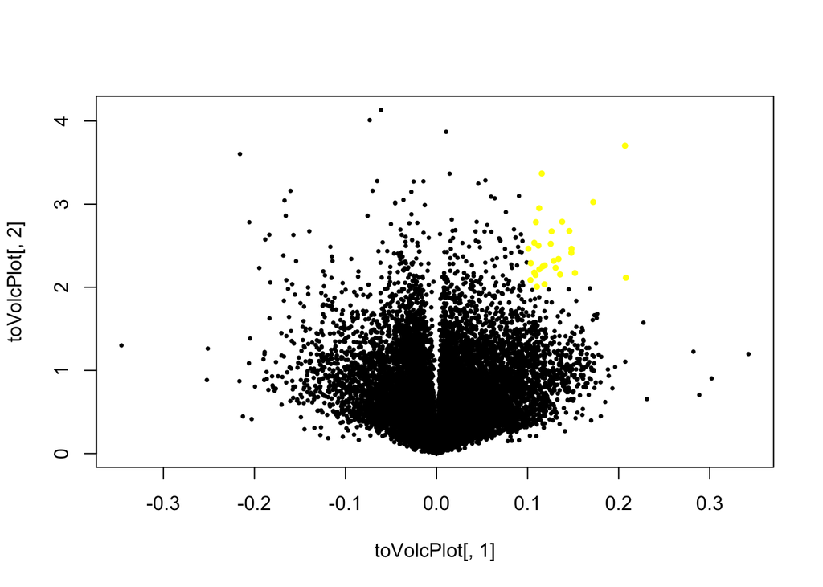

```r
points(toHighlight[,1], toHighlight[,2],pch=16,cex=0.7,col="yellow")
```

```r
plot(toVolcPlot[,1], toVolcPlot[,2],pch=16,cex=0.5)
toHighlight <- toVolcPlot[abs(toVolcPlot[,1])>0.1 & toVolcPlot[,2]>(-log10(0.01)),]
head(toHighlight)
```

```
##            delta_first20k X.log10.final_ttest_first20k_corrected.pValues_ttest.
## cg25978218      0.2069612                                              3.703878
## cg18154117     -0.2159329                                              3.603781
## cg11799650      0.1155720                                              3.368229
## cg00569500     -0.1604060                                              3.160202
## cg16125214     -0.1669493                                              3.044163
## cg04542977      0.1719873                                              3.025450
```

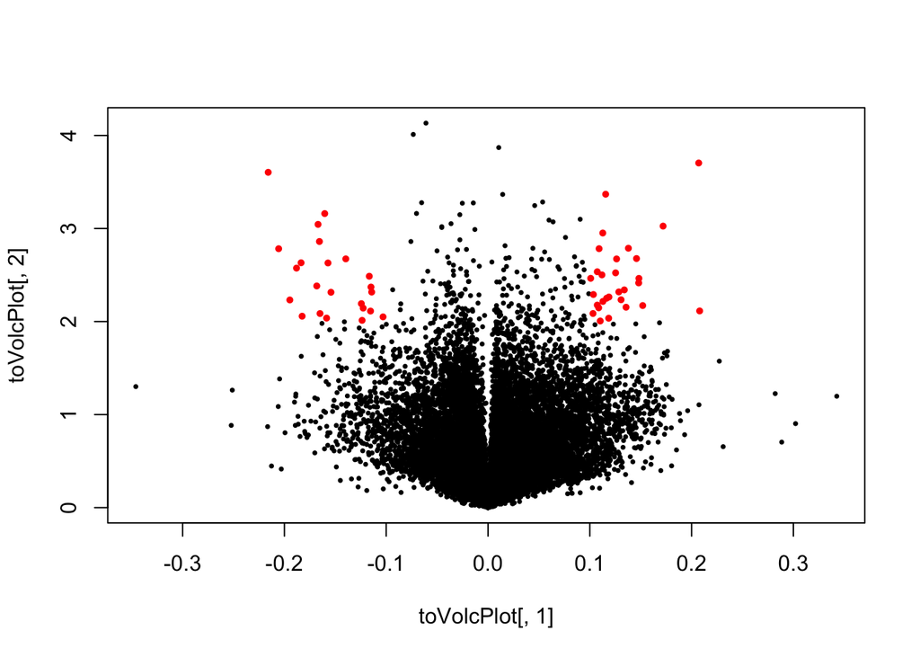

```r
points(toHighlight[,1], toHighlight[,2],pch=16,cex=0.7,col="red")
```

# CHUNK 3: Manhattan plots

We will use the “qqman” package, from the CRAN repository: to install it type: install.packages(“qqman”)

```r
library(qqman)
```

To calculate the Manhattan plot, during the lesson we will use the object final_ttest_reduced, that I prepared by applying the ttest function on a subset of the probes of the dataset. The object is in the Lesson 6 folder:

```r
load("final_ttest_reduced.RData")
```

First we have to annotate our dataframe, that is add genome annotation information for each cpg probe. We will use the Illumina450Manifest_clean object that we previously created:

```r
load('~/Dropbox/DRD_2026/2/Illumina450Manifest_clean.RData')
```

We will use the merge() function to merge the final_ttest_corrected with the Illumina450Manifest_clean object

```r
?merge
```

The merge function performs the merging by using a column which is common to two dataframes and which has the same name in the two dataframes

```r
head(Illumina450Manifest_clean)
```

```
##       IlmnID       Name AddressA_ID
## 1 cg00035864 cg00035864    31729416
## 2 cg00050873 cg00050873    32735311
## 3 cg00061679 cg00061679    28780415
## 4 cg00063477 cg00063477    16712347
## 5 cg00121626 cg00121626    19779393
## 6 cg00212031 cg00212031    29674443
##                                     AlleleA_ProbeSeq AddressB_ID
## 1 AAAACACTAACAATCTTATCCACATAAACCCTTAAATTTATCTCAAATTC
## 2 ACAAAAAAACAACACACAACTATAATAATTTTTAAAATAAATAAACCCCA    31717405
## 3 AAAACATTAAAAAACTAATTCACTACTATTTAATTACTTTATTTTCCATC
## 4 TATTCTTCCACACAAAATACTAAACRTATATTTACAAAAATACTTCCATC
## 5 AAAACTAATAAAAATAACTTACAAACCAAATACTATACCCTACAACTCTC
## 6 CCCAATTAACCACAAAAACTAAACAAATTATACAATCAAAAAAACATACA    38703326
##                                     AlleleB_ProbeSeq Infinium_Design_Type
```

[output cut: 62 more lines]

```r
head(final_ttest_reduced)
```

```
##            X9344737127_R01C02 X9344737127_R03C02 X9344737127_R06C01
## cg20794042         0.07829501         0.08373973          0.1201370
## cg04340719         0.05252592         0.05310158          0.0652381
## cg12358527         0.87801191         0.87981341          0.8652472
## cg11185549         0.13628803         0.15247124          0.2752861
## cg20218135         0.26227644         0.21476548          0.8359332
## cg07324172         0.68868893         0.66228627          0.4732796
##            X9344737127_R02C02 X9376538140_R02C01 X9376538140_R05C01
## cg20794042         0.11725255         0.08247280         0.07970218
## cg04340719         0.06359918         0.05204832         0.05412298
## cg12358527         0.86412648         0.87775107         0.87901299
## cg11185549         0.25399951         0.12302005         0.12177307
## cg20218135         0.84482192         0.29236695         0.23632145
## cg07324172         0.47617591         0.64406619         0.66539160
##            X9376538140_R01C01 X9376538140_R04C01 pValues_ttest
## cg20794042         0.11719196         0.12175898  5.442489e-07
## cg04340719         0.06423333         0.06396302  1.778325e-06
## cg12358527         0.86708185         0.86441144  7.820567e-06
## cg11185549         0.24949587         0.25091325  1.421267e-05
## cg20218135         0.82382573         0.84587250  1.428266e-05
## cg07324172         0.48627249         0.51804417  1.500840e-05
##            corrected_pValues_BH corrected_pValues_Bonf
## cg20794042            0.2642394              0.2642394
## cg04340719            0.4316990              0.8633979
## cg12358527            0.6568315              1.0000000
## cg11185549            0.6568315              1.0000000
## cg20218135            0.6568315              1.0000000
## cg07324172            0.6568315              1.0000000
```

We want to merge on the basis of the CpG probes, but unfortunately in the final_ttest_corrected object the CpG probes are stored in the rownames, not in a column. We can overcome this issue as follows:

```r
final_ttest_reduced <- data.frame(rownames(final_ttest_reduced),final_ttest_reduced)
head(final_ttest_reduced)
```

```
##            rownames.final_ttest_reduced. X9344737127_R01C02 X9344737127_R03C02
## cg20794042                    cg20794042         0.07829501         0.08373973
## cg04340719                    cg04340719         0.05252592         0.05310158
## cg12358527                    cg12358527         0.87801191         0.87981341
## cg11185549                    cg11185549         0.13628803         0.15247124
## cg20218135                    cg20218135         0.26227644         0.21476548
## cg07324172                    cg07324172         0.68868893         0.66228627
##            X9344737127_R06C01 X9344737127_R02C02 X9376538140_R02C01
## cg20794042          0.1201370         0.11725255         0.08247280
## cg04340719          0.0652381         0.06359918         0.05204832
## cg12358527          0.8652472         0.86412648         0.87775107
## cg11185549          0.2752861         0.25399951         0.12302005
## cg20218135          0.8359332         0.84482192         0.29236695
## cg07324172          0.4732796         0.47617591         0.64406619
##            X9376538140_R05C01 X9376538140_R01C01 X9376538140_R04C01
## cg20794042         0.07970218         0.11719196         0.12175898
## cg04340719         0.05412298         0.06423333         0.06396302
## cg12358527         0.87901299         0.86708185         0.86441144
## cg11185549         0.12177307         0.24949587         0.25091325
## cg20218135         0.23632145         0.82382573         0.84587250
## cg07324172         0.66539160         0.48627249         0.51804417
##            pValues_ttest corrected_pValues_BH corrected_pValues_Bonf
## cg20794042  5.442489e-07            0.2642394              0.2642394
## cg04340719  1.778325e-06            0.4316990              0.8633979
## cg12358527  7.820567e-06            0.6568315              1.0000000
## cg11185549  1.421267e-05            0.6568315              1.0000000
## cg20218135  1.428266e-05            0.6568315              1.0000000
## cg07324172  1.500840e-05            0.6568315              1.0000000
```

```r
colnames(final_ttest_reduced)
```

```
##  [1] "rownames.final_ttest_reduced." "X9344737127_R01C02"
##  [3] "X9344737127_R03C02"            "X9344737127_R06C01"
##  [5] "X9344737127_R02C02"            "X9376538140_R02C01"
##  [7] "X9376538140_R05C01"            "X9376538140_R01C01"
##  [9] "X9376538140_R04C01"            "pValues_ttest"
## [11] "corrected_pValues_BH"          "corrected_pValues_Bonf"
```

```r
colnames(final_ttest_reduced)[1] <- "IlmnID"
colnames(final_ttest_reduced)
```

```
##  [1] "IlmnID"                 "X9344737127_R01C02"     "X9344737127_R03C02"
##  [4] "X9344737127_R06C01"     "X9344737127_R02C02"     "X9376538140_R02C01"
##  [7] "X9376538140_R05C01"     "X9376538140_R01C01"     "X9376538140_R04C01"
## [10] "pValues_ttest"          "corrected_pValues_BH"   "corrected_pValues_Bonf"
```

```r
final_ttest_reduced_annotated <- merge(final_ttest_reduced, Illumina450Manifest_clean,by="IlmnID")
dim(final_ttest_reduced)
```

```
## [1] 48539    12
```

```r
dim(final_ttest_reduced_annotated)
```

```
## [1] 48539    44
```

```r
str(final_ttest_reduced_annotated)
```

```
## 'data.frame':    48539 obs. of  44 variables:
##  $ IlmnID                     : chr  "cg00000165" "cg00000714" "cg00001249" "cg00001593" ...
##  $ X9344737127_R01C02         : num  0.269 0.174 0.559 0.791 0.844 ...
##  $ X9344737127_R03C02         : num  0.252 0.145 0.605 0.807 0.833 ...
##  $ X9344737127_R06C01         : num  0.2 0.201 0.709 0.845 0.792 ...
##  $ X9344737127_R02C02         : num  0.219 0.188 0.594 0.829 0.841 ...
##  $ X9376538140_R02C01         : num  0.305 0.145 0.542 0.784 0.863 ...
##  $ X9376538140_R05C01         : num  0.266 0.128 0.492 0.783 0.845 ...
##  $ X9376538140_R01C01         : num  0.203 0.187 0.64 0.815 0.803 ...
##  $ X9376538140_R04C01         : num  0.219 0.214 0.713 0.839 0.827 ...
##  $ pValues_ttest              : num  0.00607 0.00689 0.0225 0.00331 0.06466 ...
##  $ corrected_pValues_BH       : num  0.657 0.657 0.657 0.657 0.657 ...
##  $ corrected_pValues_Bonf     : num  1 1 1 1 1 1 1 1 1 1 ...
##  $ Name                       : Factor w/ 485512 levels "cg00000029","cg00000108",..: 4 12 24 34 67 68 88 89 93 94 ...
##  $ AddressA_ID                : Factor w/ 485512 levels "10600322","10600328",..: 16431 164675 30331 298508 349158 185801 39687 183067 91531 225153 ...
```

[output cut: 30 more lines]

Note that the dataframe is automathically reordered on the basis of alphabetical order of the column used for merging

```r
head(final_ttest_reduced_annotated)
```

```
##       IlmnID X9344737127_R01C02 X9344737127_R03C02 X9344737127_R06C01
## 1 cg00000165          0.2693781          0.2523965          0.2002441
## 2 cg00000714          0.1738167          0.1448749          0.2005353
## 3 cg00001249          0.5586365          0.6054516          0.7086758
## 4 cg00001593          0.7906507          0.8066051          0.8445328
## 5 cg00002808          0.8443084          0.8328302          0.7924436
## 6 cg00002809          0.7708458          0.7646070          0.7982595
##   X9344737127_R02C02 X9376538140_R02C01 X9376538140_R05C01 X9376538140_R01C01
## 1          0.2190469          0.3047645          0.2656781          0.2026381
## 2          0.1878646          0.1448605          0.1278426          0.1871288
## 3          0.5942167          0.5415010          0.4919873          0.6395910
## 4          0.8285542          0.7835228          0.7833327          0.8149185
## 5          0.8412397          0.8634898          0.8452696          0.8031069
## 6          0.7805688          0.7594264          0.7696202          0.7753781
##   X9376538140_R04C01 pValues_ttest corrected_pValues_BH corrected_pValues_Bonf
```

[output cut: 69 more lines]

Now we can create the input for the Manhattan plot analysis. The input object should contain 4 info: probe, chromosome, position on the chromosome and p-value. We will select these columns in the final_ttest_corrected_annotated object

```r
input_Manhattan <- final_ttest_reduced_annotated[colnames(final_ttest_reduced_annotated) %in% c("IlmnID","CHR","MAPINFO","pValues_ttest")]
dim(input_Manhattan)
```

```
## [1] 48539     4
```

```r
head(input_Manhattan)
```

```
##       IlmnID pValues_ttest CHR   MAPINFO
## 1 cg00000165   0.006065725   1  91194674
## 2 cg00000714   0.006890308  19  54695678
## 3 cg00001249   0.022499353  14  60389786
## 4 cg00001593   0.003306490   1 170490434
## 5 cg00002808   0.064660966   1 223568700
## 6 cg00002809   0.021671455  17  76482353
```

```r
str(input_Manhattan)
```

```
## 'data.frame':    48539 obs. of  4 variables:
##  $ IlmnID       : chr  "cg00000165" "cg00000714" "cg00001249" "cg00001593" ...
##  $ pValues_ttest: num  0.00607 0.00689 0.0225 0.00331 0.06466 ...
##  $ CHR          : Factor w/ 24 levels "1","10","11",..: 1 11 6 1 1 9 11 1 20 8 ...
##  $ MAPINFO      : int  91194674 54695678 60389786 170490434 223568700 76482353 17336525 45080600 15725862 66586745 ...
```

```r
levels(input_Manhattan$CHR)
```

```
##  [1] "1"  "10" "11" "12" "13" "14" "15" "16" "17" "18" "19" "2"  "20" "21" "22"
## [16] "3"  "4"  "5"  "6"  "7"  "8"  "9"  "X"  "Y"
```

It is better to reorder the levels of the column CHR

```r
order_chr <- c("1","2","3","4","5","6","7","8","9","10","11","12","13","14","15","16","17","18","19","20","21","22","X","Y")
input_Manhattan$CHR <- factor(input_Manhattan$CHR,levels=order_chr )
levels(input_Manhattan$CHR)
```

```
##  [1] "1"  "2"  "3"  "4"  "5"  "6"  "7"  "8"  "9"  "10" "11" "12" "13" "14" "15"
## [16] "16" "17" "18" "19" "20" "21" "22" "X"  "Y"
```

The function that we will use is “manhattan”

```r
?manhattan
```

As you see, the column “CHR” should be numeric –> we will convert factors to numbers

```r
input_Manhattan$CHR <- as.numeric(input_Manhattan$CHR)
table(input_Manhattan$CHR)
```

```
##
##    1    2    3    4    5    6    7    8    9   10   11   12   13   14   15   16
## 4685 3481 2515 2046 2432 3661 3001 2095  986 2438 2879 2453 1228 1507 1525 2196
##   17   18   19   20   21   22   23   24
## 2787  592 2552 1037  424  855 1123   41
```

and finally we can produce our Manhattan plot

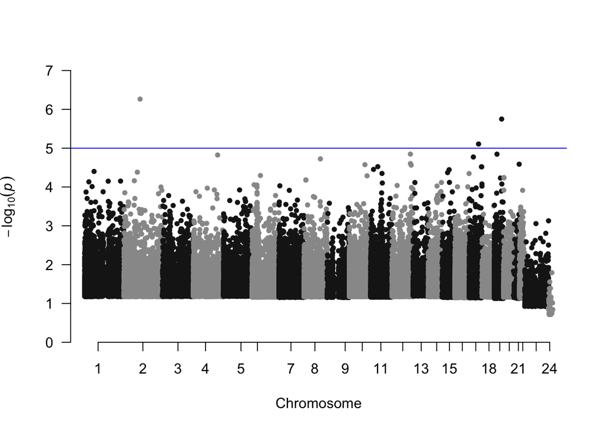

```r
manhattan(input_Manhattan, snp="IlmnID",chr="CHR", bp="MAPINFO", p="pValues_ttest" )
```

what is the blue line?

```r
-log10(0.00001)
```

```
## [1] 5
```

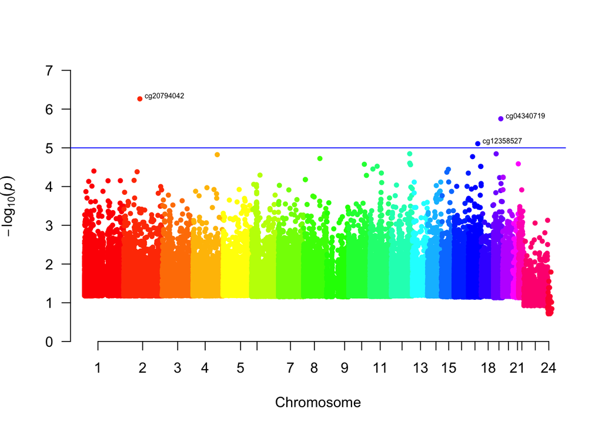

```r
manhattan(input_Manhattan, snp="IlmnID",chr="CHR", bp="MAPINFO", p="pValues_ttest",annotatePval = 0.00001,col=rainbow(24) )
```

# CHUNK 4: heatmaps with hierarchical clustering

We need the gplots package from CRAN repository

```r
# install.packages("gplots")
library(gplots)
```

We will use the function heatmap.2.

```r
?heatmap.2
```

It wants as input a matrix. As an heatmap on several thousands of probes is computationally demanding, for our analysis we will use just the top 100 most significant CpG probes. We will extract only beta values for these top 100 probes and convert them in a matrix:

```r
input_heatmap=as.matrix(final_ttest_first20k[1:100,1:8])
```

The default method for distance is “euclidean” (click on “dist” in distfun paragraph), while the default function for hierarchical clustering is “complete” (click on “hclust” in hclustfun paragraph)

Finally, we we create a bar of colors for Group A or Group B membership

```r
pheno$Group
```

```
## [1] A A B B A A B B
## Levels: A B
```

```r
colorbar <- c("green","green","orange","orange","green","green","orange","orange")
```

In the following lines we will compare the results of hierchical clustering using different methods.

Complete (default options)

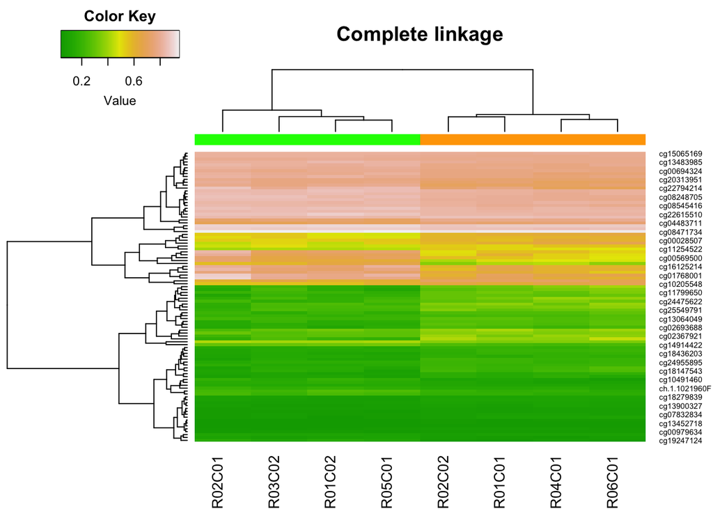

```r
heatmap.2(input_heatmap,col=terrain.colors(100),Rowv=T,Colv=T,dendrogram="both",key=T,ColSideColors=colorbar,density.info="none",trace="none",scale="none",symm=F,main="Complete linkage")
```

You can see that hierarchical clustering divides well group A and group B samples; in addition, you see that some probes are hypermethylated in Group A compared to group B, others are hypomethylated.

Single

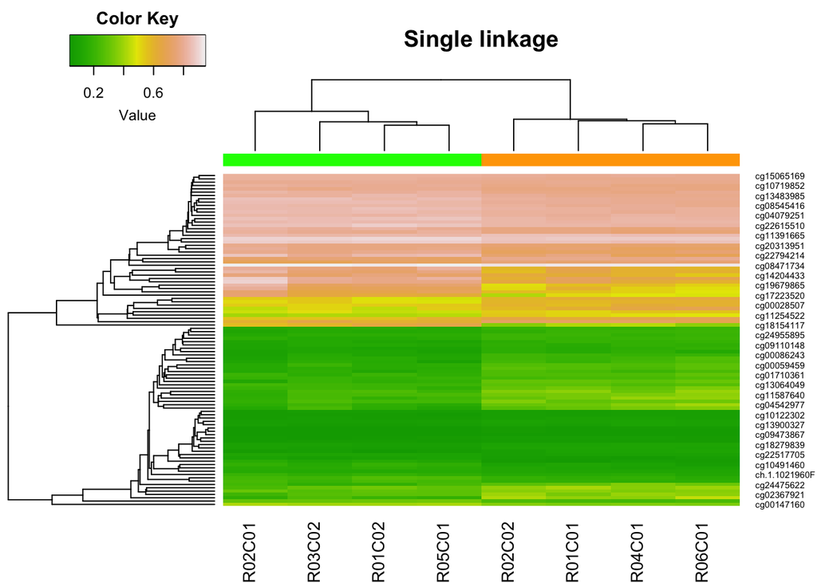

```r
heatmap.2(input_heatmap,col=terrain.colors(100),Rowv=T,Colv=T,hclustfun = function(x) hclust(x,method = 'single'),dendrogram="both",key=T,ColSideColors=colorbar,density.info="none",trace="none",scale="none",symm=F,main="Single linkage")
```

Average

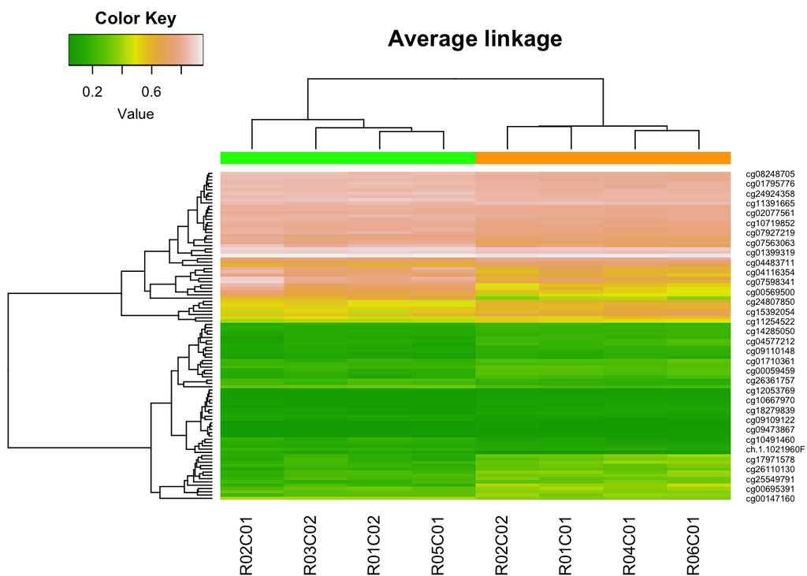

```r
heatmap.2(input_heatmap,col=terrain.colors(100),Rowv=T,Colv=T,hclustfun = function(x) hclust(x,method = 'average'),dendrogram="both",key=T,ColSideColors=colorbar,density.info="none",trace="none",scale="none",symm=F,main="Average linkage")
```

You can set your palette of colors

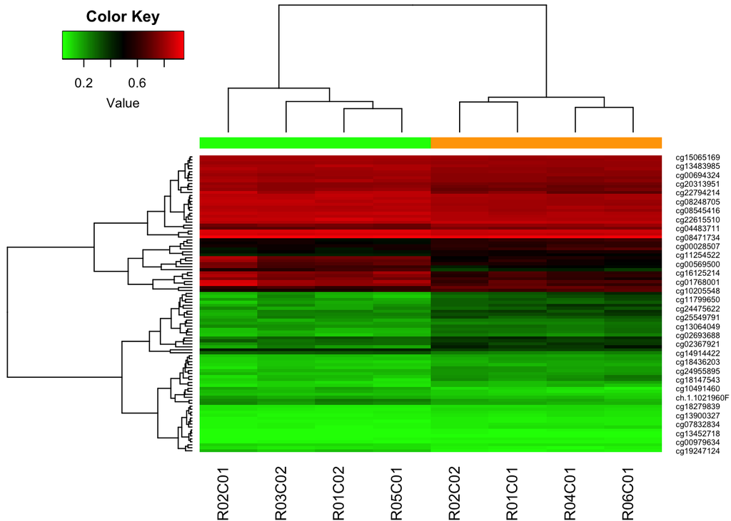

```r
col2=colorRampPalette(c("green","black","red"))(100)
heatmap.2(input_heatmap,col=col2,Rowv=T,Colv=T,dendrogram="both",key=T,ColSideColors=colorbar,density.info="none",trace="none",scale="none",symm=F)
```